# Transit Oriented Displacement? Has Minnesota’s Green Line Propagated Gentrification?

Brian Pryzby

November 16, 2023

## Group Members and Contribution

At this point, all work as been done by myself with the intention of merging paths with Gugo following the completion of this presentation

## Research Question and Motivation

Has the Twin Cities’ Green Line light rail line contributed to gentrification of the surrounding areas? I seek to answer this question using change in four primary indicators between 2013 and 2019, mean property value, median household income, poverty, and percentage white population. I also explore changes in public transit usage to further contextualize the impact of the line. This question was inspired by knowledge of significant development plans along University Ave which are concurrent with the development of the Green Line, such as Allianz Field and “gentrification building” style housing developments in Prospect Park and at the intersection of Hamline and University. The length of University Ave has long been home to a diverse working class community, and I seek to explore if the Green Line has kick-started the process of gentrifying this area.

## Workflow, Dataset and Results

**load packages and define variables**

```r
library(tidycensus)
library(tidyverse)
library(sf)
VARS <- c(income = "B19013_001", popTotal = "B01003_001", popWhite = "B02001_002", povertyTotal = "B17010_001", povertyUnder = "B17010_002", transitTotal = "B08301_001", transitUsage = "B08301_010", employmentTotal = "B23025_001", unemployment = "B23025_002", propertyValue = "B25077_001")
```

**query census api**

**census data cleaning**

```r
ramsey13pivot <- ramsey13 %>%
  select(-"moe") %>%
  pivot_wider(names_from = "variable", values_from = "estimate") %>%
  group_by("NAME")

ramsey13clean <-  ramsey13pivot %>%
  mutate(whitePerc13 = popWhite/popTotal) %>%
  mutate(transitPerc13 = transitUsage/transitTotal) %>%
  mutate(povertyPerc13 = povertyUnder/povertyTotal)

hennepin13pivot <- hennepin13 %>%
  select(-"moe") %>%
  pivot_wider(names_from = "variable", values_from = "estimate") %>%
  group_by("NAME")

hennepin13clean <-  hennepin13pivot %>%
  mutate(whitePerc13 = popWhite/popTotal) %>%
  mutate(transitPerc13 = transitUsage/transitTotal) %>%
  mutate(povertyPerc13 = povertyUnder/povertyTotal)

ramsey19pivot <- ramsey19 %>%
  select(-"moe") %>%
  pivot_wider(names_from = "variable", values_from = "estimate") %>%
  group_by("NAME")

ramsey19clean <-  ramsey19pivot %>%
  mutate(whitePerc19 = popWhite/popTotal) %>%
  mutate(transitPerc19 = transitUsage/transitTotal) %>%
  mutate(povertyPerc19 = povertyUnder/povertyTotal) %>%
  st_drop_geometry()

hennepin19pivot <- hennepin19 %>%
  select(-"moe") %>%
  pivot_wider(names_from = "variable", values_from = "estimate") %>%
  group_by("NAME")

hennepin19clean <-  hennepin19pivot %>%
  mutate(whitePerc19 = popWhite/popTotal) %>%
  mutate(transitPerc19 = transitUsage/transitTotal) %>%
  mutate(povertyPerc19 = povertyUnder/povertyTotal) %>%
  st_drop_geometry()

ramsey <- left_join(x=ramsey13clean, y=ramsey19clean, by="GEOID")
hennepin <- left_join(x=hennepin13clean, y=hennepin19clean, by="GEOID")

ramsey <- ramsey %>%
  mutate(whiteChange = whitePerc19 - whitePerc13) %>%
  mutate(transitChange = transitPerc19 - transitPerc13) %>%
  mutate(povertyChange = povertyPerc19 - povertyPerc13) %>%
  mutate(incomeChange = income.y - income.x) %>%
  mutate(propertyValueChange = propertyValue.y - propertyValue.x)

hennepin <- hennepin  %>%
  mutate(whiteChange = whitePerc19 - whitePerc13) %>%
  mutate(transitChange = transitPerc19 - transitPerc13) %>%
  mutate(povertyChange = povertyPerc19 - povertyPerc13) %>%
  mutate(incomeChange = income.y - income.x) %>%
  mutate(propertyValueChange = propertyValue.y - propertyValue.x)

bothCounties <- rbind(hennepin, ramsey)
```

I use the dataset above for my analysis, which contains variables from the 5-year ACS queried from the official Census API. I focus on median household income, mean property value, poverty, % white population and reliance on public transportation. Data is gathered at the block group aggregation and is compared between 2013 and 2019 measurements.

**load and buffer stations**

```r
stations <- read_sf("stations/GreenLineStations.shp")

crs_to_use <-st_crs(ramsey)
crs_epsg <- crs_to_use$epsg

stations <- st_transform(stations,crs=crs_epsg)

stations <- stations %>%
  select(-c("Notes", "created_us", "created_da", "last_edite", "last_edi_1", "NoteType"))

#400 meters
stations_buffer <- st_buffer(stations, 400)
```

```
## st_as_s2(): dropping Z and/or M coordinate
```

**spatial query of block group intersections**

```r
query <- st_intersects(bothCounties, stations_buffer, sparse=FALSE)
query <- matrix(apply(query, 1, any), ncol = 1)
bothIntersect <- filter(bothCounties, as.vector(query))
```

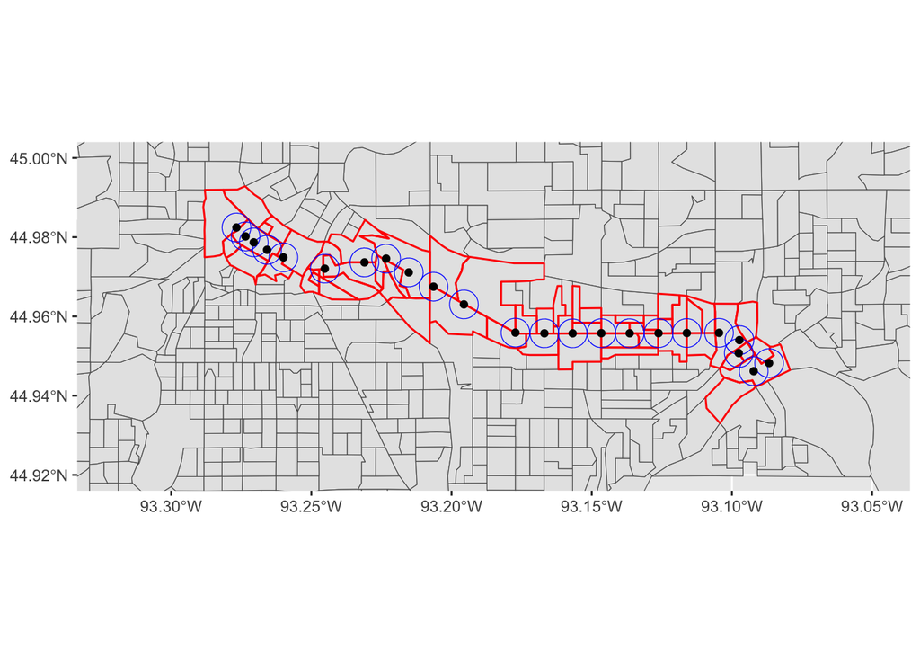

```r
bothIntersect %>%
  ggplot() +
  geom_sf(data = bothCounties) +
  geom_sf(alpha = 0, color='red', lwd = 0.5) +
  geom_sf(data = stations_buffer, alpha = 0, color = 'blue') +
  geom_sf(data = stations) +
  xlim(c(-93.32, -93.05)) +
  ylim(c(44.92, 45))
```

**visualizations of variables**

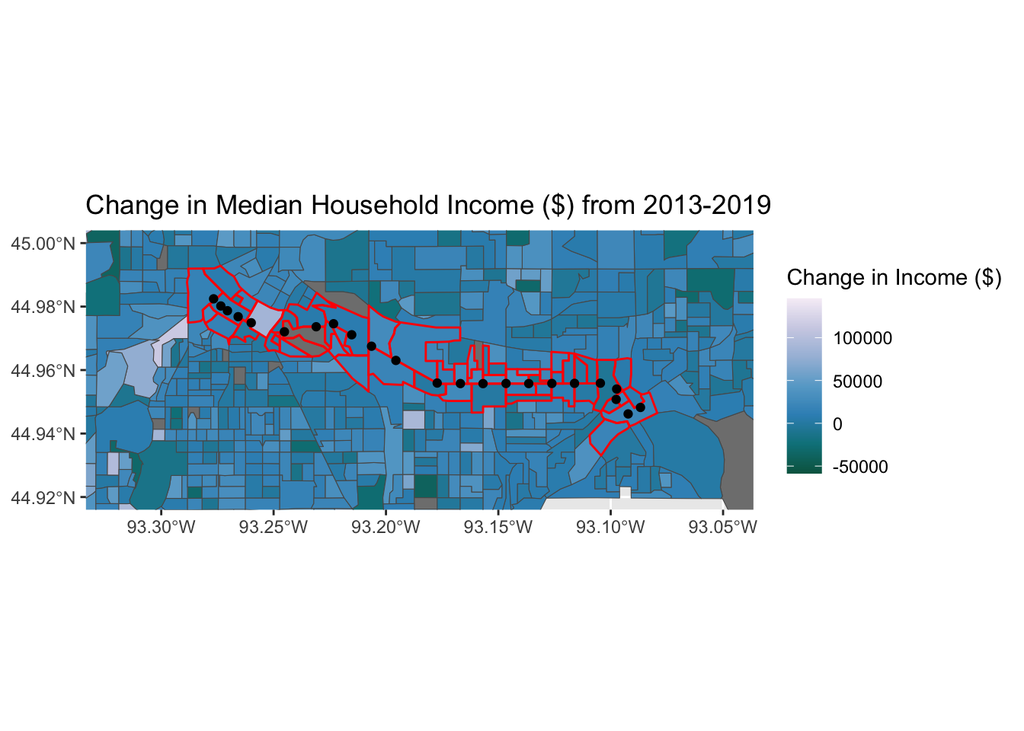

```r
stations %>%
  ggplot() +
  geom_sf(data = bothCounties, aes(fill = incomeChange)) +
  geom_sf(data= bothIntersect, alpha = 0, color = 'red', lwd = 0.5) +
  geom_sf() +
  scale_fill_distiller(palette = "PuBuGn",
                       name = "Change in Income ($)") +
  xlim(c(-93.32, -93.05)) +
  ylim(c(44.92, 45)) +
  ggtitle("Change in Median Household Income ($) from 2013-2019")
```